# Labo 2

Oscar Centeno Mora

# Análisis por Componentes Principales (PCA)

EL presente laboratorio expone la técnica de PCA. Este mostrará:

1. Funciones para realizar el PCA
2. El contenido del PCA
3. Variancia explicada por el PCA
4. Las proyecciones
5. Otros elementos de análisis

## Sitios web de referencia

https://uc-r.github.io/pca

https://rpubs.com/Joaquin_AR/287787

https://www.rdocumentation.org/packages/FactoMineR/versions/1.41/topics/PCA

https://statquest.org/2017/11/27/statquest-pca-in-r-clearly-explained/

http://www.math.u-bordeaux.fr/~mchave100p/wordpress/wp-content/uploads/2013/10/ACP-TP.pdf

https://www.datacamp.com/community/tutorials/pca-analysis-r

https://www.r-bloggers.com/computing-and-visualizing-pca-in-r/

http://www.sthda.com/english/articles/31-principal-component-methods-in-r-practical-guide/118-principal-component-analysis-in-r-prcomp-vs-princomp/

https://www.analyticsvidhya.com/blog/2016/03/practical-guide-principal-component-analysis-python/

https://datascienceplus.com/principal-component-analysis-pca-in-r/

http://www.gastonsanchez.com/visually-enforced/how-to/2012/06/17/PCA-in-R/

## Datos del laboratorio

Para el siguiente ejemplo utilizaremos los datos de “decathlon2”

La estructura del archivo decathlon2 es:

```
## 'data.frame':    27 obs. of  13 variables:
##  $ X100m       : num  11 10.8 11 11.3 11.1 ...
##  $ Long.jump   : num  7.58 7.4 7.23 7.09 7.3 7.31 6.81 7.56 6.97 7.27 ...
##  $ Shot.put    : num  14.8 14.3 14.2 15.2 13.5 ...
##  $ High.jump   : num  2.07 1.86 1.92 2.1 2.01 2.13 1.95 1.86 1.95 1.98 ...
##  $ X400m       : num  49.8 49.4 48.9 50.4 48.6 ...
##  $ X110m.hurdle: num  14.7 14.1 15 15.3 14.2 ...
##  $ Discus      : num  43.8 50.7 40.9 46.3 45.7 ...
##  $ Pole.vault  : num  5.02 4.92 5.32 4.72 4.42 4.42 4.92 4.82 4.72 4.62 ...
##  $ Javeline    : num  63.2 60.1 62.8 63.4 55.4 ...
##  $ X1500m      : num  292 302 280 276 268 ...
##  $ Rank        : int  1 2 4 5 7 8 9 10 11 12 ...
##  $ Points      : int  8217 8122 8067 8036 8004 7995 7802 7733 7708 7651 ...
##  $ Competition : Factor w/ 2 levels "Decastar","OlympicG": 1 1 1 1 1 1 1 1 1 1 ...
```

## Las funciones y librerías del PCA

Las funciones y librerías parar realizar el PCA en R pueden ser:

1. prcomp() (stats)

```r
pca1 = prcomp(USArrests, scale. = TRUE)
```

2. princomp() (stats)

```r
pca2 = princomp(USArrests, cor = TRUE)
```

3. PCA() (FactoMineR)

```r
pca3 = PCA(USArrests, graph = FALSE)
```

4. dudi.pca() (ade4)

```r
pca4 = dudi.pca(USArrests, nf = 5, scannf = FALSE)
```

5. acp() (amap)

```r
pca5 = acp(USArrests)
```

## Elementos de extracción del PCA

Del PCA podríamos extraer :

1. Los Eigenvalues

```r
eig.val <- get_eigenvalue(res.pca)
eig.val
```

```
##        eigenvalue variance.percent cumulative.variance.percent
## Dim.1   4.1242133        41.242133                    41.24213
## Dim.2   1.8385309        18.385309                    59.62744
## Dim.3   1.2391403        12.391403                    72.01885
## Dim.4   0.8194402         8.194402                    80.21325
## Dim.5   0.7015528         7.015528                    87.22878
## Dim.6   0.4228828         4.228828                    91.45760
## Dim.7   0.3025817         3.025817                    94.48342
## Dim.8   0.2744700         2.744700                    97.22812
## Dim.9   0.1552169         1.552169                    98.78029
## Dim.10  0.1219710         1.219710                   100.00000
```

2. Los loadings o cargas

```r
head(res.pca$rotation)
```

```
##                     PC1         PC2        PC3         PC4        PC5
## X100m        -0.4188591  0.13230683 -0.2708996  0.03708806 -0.2321476
## Long.jump     0.3910648 -0.20713320  0.1711752 -0.12746997  0.2783669
## Shot.put      0.3613881 -0.06298590 -0.4649778  0.14191803 -0.2970589
## High.jump     0.3004132  0.34309742 -0.2965280  0.15968342  0.4807859
## X400m        -0.3454786 -0.21400770 -0.2547084  0.47592968  0.1240569
## X110m.hurdle -0.3762651  0.01824645 -0.4032525 -0.01866477  0.2676975
##                       PC6         PC7         PC8        PC9        PC10
## X100m         0.054398099 -0.16604375 -0.19988005 -0.7692464  0.12718339
## Long.jump    -0.051865558 -0.28056361 -0.75850657 -0.1309459  0.08509665
## Shot.put     -0.368739186 -0.01797323  0.04649571  0.1212931  0.62263702
## High.jump    -0.437716883  0.05118848  0.16111045 -0.2846322 -0.38244596
## X400m        -0.075796432  0.52012255 -0.44579641  0.2085418 -0.09784197
## X110m.hurdle  0.004048005 -0.67276768 -0.01592804  0.4105842 -0.04475363
```

3. Los distintos valores de los individuos

```r
# Resultados de los individuos
res.ind <- get_pca_ind(res.pca)
res.ind$coord          # Coordinadas
```

```
##                  Dim.1      Dim.2       Dim.3       Dim.4         Dim.5
## SEBRLE       0.1912074 -1.5541282 -0.62836882  0.08205241  1.1426139415
## CLAY         0.7901217 -2.4204156  1.35688701  1.26984296 -0.8068483724
## BERNARD     -1.3292592 -1.6118687 -0.19614996 -1.92092203  0.0823428202
## YURKOV      -0.8694134  0.4328779 -2.47398223  0.69723814  0.3988584116
## ZSIVOCZKY   -0.1057450  2.0233632  1.30493117 -0.09929630 -0.1970241089
## McMULLEN     0.1185550  0.9916237  0.84355824  1.31215266  1.5858708644
## MARTINEAU   -2.3923532  1.2849234 -0.89816842  0.37309771 -2.2433515889
## HERNU       -1.8910497 -1.1784614 -0.15641037  0.89130068 -0.1267412520
## BARRAS      -1.7744575  0.4125321  0.65817750  0.22872866 -0.2338366980
## NOOL        -2.7770058  1.5726757  0.60724821 -1.55548081  1.4241839810
## BOURGUIGNON -4.4137335 -1.2635770 -0.01003734  0.66675478  0.4191518468
## Sebrle       3.4514485 -1.2169193 -1.67816711 -0.80870696 -0.0250530746
## Clay         3.3162243 -1.6232908 -0.61840443 -0.31679906  0.5691645854
## Karpov       4.0703560  0.7983510  1.01501662  0.31336354 -0.7974259553
## Macey        1.8484623  2.0638828 -0.97928455  0.58469073 -0.0002157834
## Warners      1.3873514 -0.2819083  1.99969621 -1.01959817 -0.0405401497
## Zsivoczky    0.4715533  0.9267436 -1.72815525 -0.18483138  0.4073029909
## Hernu        0.2763118  1.1657260  0.17056375 -0.84869401 -0.6894795441
## Bernard      1.3672590  1.4780354  0.83137913  0.74531557  0.8598016482
## Schwarzl    -0.7102777 -0.6584251  1.04075176 -0.92717510 -0.2887568007
## Pogorelov   -0.2143524 -0.8610557  0.29761010  1.35560294 -0.0150531057
## Schoenbeck  -0.4953166 -1.3000530  0.10300360 -0.24927712 -0.6452257128
## Barras      -0.3158867  0.8193681 -0.86169481 -0.58935985 -0.7797389436
##                   Dim.6       Dim.7        Dim.8        Dim.9      Dim.10
## SEBRLE      -0.46389755 -0.20796012  0.043460568 -0.659344137  0.03273238
## CLAY         1.30420016 -0.21291866  0.617240611 -0.060125359 -0.31716015
## BERNARD     -0.40062867 -0.40643754  0.703856040  0.170083313 -0.09908142
## YURKOV       0.10286344 -0.32487448  0.114996135 -0.109524039 -0.11969720
## ZSIVOCZKY    0.89554111  0.08825624 -0.202341299 -0.523103099 -0.34842265
## McMULLEN     0.18657283  0.47828432  0.293089967 -0.105623196 -0.39317797
## MARTINEAU   -0.45666350 -0.29975522 -0.291628488 -0.223417655 -0.61640509
## HERNU        0.43623496 -0.56609980 -1.529404317  0.006184409  0.55368016
## BARRAS       0.09026010  0.21594095  0.682583078 -0.669282042  0.53085420
## NOOL         0.49716399 -0.53205687 -0.433385655 -0.115777808 -0.09622142
## BOURGUIGNON -0.08200220 -0.59833739  0.563619921  0.525814030  0.05855882
## Sebrle      -0.08279306  0.01016177 -0.030585843 -0.847210682  0.21970353
## Clay         0.77715960  0.25750851 -0.580638301  0.409776590 -0.61601933
## Karpov      -0.32958134 -1.36365568  0.345306381  0.193055107  0.21721852
## Macey       -0.19728082 -0.26927772 -0.363219506  0.368260269  0.21249474
## Warners     -0.55673300 -0.26739400 -0.109470797  0.180283071  0.24208420
## Zsivoczky   -0.11383190  0.03991159  0.538039776  0.585966156 -0.14271715
## Hernu       -0.33168404  0.44308686  0.247293566  0.066908586 -0.20868256
## Bernard     -0.32806564  0.36357920  0.006165316  0.279488675  0.32067773
## Schwarzl    -0.68891640  0.56568604 -0.687053339 -0.008358849 -0.30211546
## Pogorelov   -1.59379599  0.78370119 -0.037623661 -0.130531397 -0.03697576
## Schoenbeck   0.16172381  0.85752368 -0.255850722  0.564222295  0.29680481
## Barras       1.17415412  0.94512710  0.365550568  0.102255763  0.61186706
```

```r
res.ind$contrib        # Contribución al PCs
```

```
##                   Dim.1      Dim.2        Dim.3       Dim.4        Dim.5
## SEBRLE       0.03854254  5.7118249 1.385418e+00  0.03572215 8.091161e+00
## CLAY         0.65814114 13.8541889 6.460097e+00  8.55568792 4.034555e+00
## BERNARD      1.86273218  6.1441319 1.349983e-01 19.57827284 4.202070e-02
## YURKOV       0.79686310  0.4431309 2.147558e+01  2.57939100 9.859373e-01
## ZSIVOCZKY    0.01178829  9.6816398 5.974848e+00  0.05231437 2.405750e-01
## McMULLEN     0.01481737  2.3253860 2.496789e+00  9.13531719 1.558646e+01
## MARTINEAU    6.03367104  3.9044125 2.830527e+00  0.73858431 3.118936e+01
## HERNU        3.76996156  3.2842176 8.583863e-02  4.21505626 9.955149e-02
## BARRAS       3.31942012  0.4024544 1.519980e+00  0.27758505 3.388731e-01
## NOOL         8.12988880  5.8489726 1.293851e+00 12.83761115 1.257025e+01
## BOURGUIGNON 20.53729577  3.7757623 3.534995e-04  2.35877858 1.088816e+00
## Sebrle      12.55838616  3.5020697 9.881482e+00  3.47006223 3.889859e-03
## Clay        11.59361384  6.2315181 1.341828e+00  0.53250375 2.007648e+00
## Karpov      17.46609555  1.5072627 3.614914e+00  0.52101693 3.940874e+00
## Macey        3.60207087 10.0732890 3.364879e+00  1.81387486 2.885677e-07
## Warners      2.02910262  0.1879390 1.403071e+01  5.51585696 1.018550e-02
## Zsivoczky    0.23441891  2.0310492 1.047894e+01  0.18126182 1.028128e+00
## Hernu        0.08048777  3.2136178 1.020764e-01  3.82170515 2.946148e+00
## Bernard      1.97075488  5.1661961 2.425213e+00  2.94737426 4.581507e+00
## Schwarzl     0.53184785  1.0252129 3.800546e+00  4.56119277 5.167449e-01
## Pogorelov    0.04843819  1.7533304 3.107757e-01  9.75034337 1.404313e-03
## Schoenbeck   0.25864068  3.9969003 3.722687e-02  0.32970059 2.580092e+00
## Barras       0.10519467  1.5876667 2.605305e+00  1.84296038 3.767994e+00
##                   Dim.6        Dim.7        Dim.8        Dim.9      Dim.10
## SEBRLE       2.21256620  0.621426384 2.992045e-02 12.177477305  0.03819185
## CLAY        17.48801877  0.651413899 6.035125e+00  0.101262442  3.58568943
## BERNARD      1.65019840  2.373652810 7.847747e+00  0.810319793  0.34994507
## YURKOV       0.10878629  1.516564073 2.094806e-01  0.336009790  0.51072064
## ZSIVOCZKY    8.24561722  0.111923276 6.485544e-01  7.664919832  4.32741147
## McMULLEN     0.35788945  3.287016354 1.360753e+00  0.312501167  5.51053518
## MARTINEAU    2.14409841  1.291109482 1.347216e+00  1.398195851 13.54402896
## HERNU        1.95655942  4.604850849 3.705288e+01  0.001071345 10.92781554
## BARRAS       0.08376135  0.670038259 7.380544e+00 12.547331617 10.04537028
## NOOL         2.54127369  4.067669683 2.975270e+00  0.375477289  0.33003418
## BOURGUIGNON  0.06913582  5.144247534 5.032108e+00  7.744571086  0.12223626
## Sebrle       0.07047579  0.001483775 1.481898e-02 20.105546253  1.72063803
## Clay         6.20972751  0.952824148 5.340583e+00  4.703566841 13.52708188
## Karpov       1.11680500 26.720158115 1.888802e+00  1.043988269  1.68193477
## Macey        0.40014909  1.041910483 2.089853e+00  3.798767930  1.60957713
## Warners      3.18673563  1.027384225 1.898339e-01  0.910422384  2.08904756
## Zsivoczky    0.13322327  0.022889042 4.585705e+00  9.617852173  0.72605208
## Hernu        1.13110069  2.821027418 9.687304e-01  0.125399768  1.55234328
## Bernard      1.10655655  1.899449022 6.021268e-04  2.188071254  3.66566729
## Schwarzl     4.87961053  4.598122119 7.477531e+00  0.001957159  3.25357879
## Pogorelov   26.11665608  8.825322559 2.242329e-02  0.477268755  0.04873597
## Schoenbeck   0.26890572 10.566272800 1.036933e+00  8.917302863  3.14020004
## Barras      14.17432302 12.835417603 2.116763e+00  0.292892746 13.34533825
```

```r
res.ind$cos2           # Calidad de la representación
```

```
##                   Dim.1      Dim.2        Dim.3       Dim.4        Dim.5
## SEBRLE      0.007530179 0.49747323 8.132523e-02 0.001386688 2.689027e-01
## CLAY        0.048701249 0.45701660 1.436281e-01 0.125791741 5.078506e-02
## BERNARD     0.197199804 0.28996555 4.294015e-03 0.411819183 7.567259e-04
## YURKOV      0.096109800 0.02382571 7.782303e-01 0.061812637 2.022798e-02
## ZSIVOCZKY   0.001574385 0.57641944 2.397542e-01 0.001388216 5.465497e-03
## McMULLEN    0.002175437 0.15219499 1.101379e-01 0.266486530 3.892621e-01
## MARTINEAU   0.404013915 0.11654676 5.694575e-02 0.009826320 3.552552e-01
## HERNU       0.399282749 0.15506199 2.731529e-03 0.088699901 1.793538e-03
## BARRAS      0.616241975 0.03330700 8.478249e-02 0.010239088 1.070152e-02
## NOOL        0.489872515 0.15711146 2.342405e-02 0.153694675 1.288433e-01
## BOURGUIGNON 0.859698130 0.07045912 4.446015e-06 0.019618511 7.753120e-03
## Sebrle      0.675380606 0.08395940 1.596674e-01 0.037079012 3.558507e-05
## Clay        0.687592867 0.16475409 2.391051e-02 0.006274965 2.025440e-02
## Karpov      0.783666922 0.03014772 4.873187e-02 0.004644764 3.007790e-02
## Macey       0.363436037 0.45308203 1.020057e-01 0.036362957 4.952707e-09
## Warners     0.255651956 0.01055582 5.311341e-01 0.138081100 2.182965e-04
## Zsivoczky   0.045053176 0.17401353 6.051030e-01 0.006921739 3.361236e-02
## Hernu       0.024824321 0.44184663 9.459148e-03 0.234196727 1.545686e-01
## Bernard     0.289347476 0.33813318 1.069834e-01 0.085980212 1.144234e-01
## Schwarzl    0.116721435 0.10030142 2.506043e-01 0.198892209 1.929118e-02
## Pogorelov   0.007803472 0.12591966 1.504272e-02 0.312101619 3.848427e-05
## Schoenbeck  0.067070098 0.46204603 2.900467e-03 0.016987442 1.138116e-01
## Barras      0.018972684 0.12765099 1.411800e-01 0.066043061 1.156018e-01
##                    Dim.6        Dim.7        Dim.8        Dim.9
## SEBRLE      0.0443241299 8.907507e-03 3.890334e-04 8.954067e-02
## CLAY        0.1326907339 3.536548e-03 2.972084e-02 2.820119e-04
## BERNARD     0.0179131165 1.843634e-02 5.529104e-02 3.228572e-03
## YURKOV      0.0013453555 1.341980e-02 1.681440e-03 1.525225e-03
## ZSIVOCZKY   0.1129176906 1.096685e-03 5.764478e-03 3.852703e-02
## McMULLEN    0.0053876990 3.540616e-02 1.329562e-02 1.726733e-03
## MARTINEAU   0.0147210347 6.342774e-03 6.003515e-03 3.523552e-03
## HERNU       0.0212478795 3.578167e-02 2.611676e-01 4.270425e-06
## BARRAS      0.0015944528 9.126203e-03 9.118662e-02 8.766746e-02
## NOOL        0.0157010551 1.798232e-02 1.193105e-02 8.514912e-04
## BOURGUIGNON 0.0002967459 1.579887e-02 1.401866e-02 1.220108e-02
## Sebrle      0.0003886276 5.854423e-06 5.303795e-05 4.069384e-02
## Clay        0.0377627839 4.145976e-03 2.107924e-02 1.049876e-02
## Karpov      0.0051379747 8.795817e-02 5.639959e-03 1.762907e-03
## Macey       0.0041397727 7.712721e-03 1.403282e-02 1.442502e-02
```

[output cut: 17 more lines]

```
## BARRAS      0.0551531863
## NOOL        0.0005881295
## BOURGUIGNON 0.0001513277
## Sebrle      0.0027366539
## Clay        0.0237264222
## Karpov      0.0022318265
## Macey       0.0048028954
## Warners     0.0077841113
## Zsivoczky   0.0041268259
## Hernu       0.0141595965
## Bernard     0.0159167991
## Schwarzl    0.0211173850
## Pogorelov   0.0002322016
## Schoenbeck  0.0240826922
## Barras      0.0711836486
```

4. Los distintos valores de las variables

```r
# Resultado de las variables
res.var <- get_pca_var(res.pca)
res.var$coord          # Coordinadas
```

```
##                     Dim.1       Dim.2       Dim.3       Dim.4      Dim.5
## X100m        -0.850625692  0.17939806 -0.30155643  0.03357320 -0.1944440
## Long.jump     0.794180641 -0.28085695  0.19054653 -0.11538956  0.2331567
## Shot.put      0.733912733 -0.08540412 -0.51759781  0.12846837 -0.2488129
## High.jump     0.610083985  0.46521415 -0.33008517  0.14455012  0.4027002
## X400m        -0.701603377 -0.29017826 -0.28353292  0.43082552  0.1039085
## X110m.hurdle -0.764125197  0.02474081 -0.44888733 -0.01689589  0.2242200
## Discus        0.743209016 -0.04966086 -0.17652518  0.39500915 -0.4082391
## Pole.vault   -0.217268042 -0.80745110 -0.09405773 -0.33898477 -0.2216853
## Javeline      0.428226639 -0.38610928 -0.60412432 -0.33173454  0.1978128
## X1500m        0.004278487 -0.78448019  0.21947068  0.44800961  0.2632527
##                     Dim.6        Dim.7        Dim.8       Dim.9
## X100m         0.035374780 -0.091336386 -0.104716925 -0.30306448
## Long.jump    -0.033727883 -0.154330810 -0.397380703 -0.05158951
## Shot.put     -0.239789034 -0.009886612  0.024359049  0.04778655
## High.jump    -0.284644846  0.028157465  0.084405578 -0.11213822
## X400m        -0.049289996  0.286106008 -0.233552216  0.08216041
## X110m.hurdle  0.002632395 -0.370072158 -0.008344682  0.16176025
## Discus        0.198544870 -0.142725641 -0.039559255  0.01336209
## Pole.vault   -0.327464549 -0.010393176  0.032914942 -0.02576874
## Javeline      0.362097598  0.133564318  0.052841099 -0.04045397
## X1500m        0.042050151 -0.111367083  0.194469730 -0.10224014
##                    Dim.10
## X100m         0.044417974
## Long.jump     0.029719453
## Shot.put      0.217451948
## High.jump    -0.133566774
## X400m        -0.034170673
## X110m.hurdle -0.015629914
## Discus       -0.172590426
## Pole.vault   -0.137211339
## Javeline     -0.003854347
## X1500m        0.062834809
```

```r
res.var$contrib        # Contribución al PCs
```

```
##                     Dim.1      Dim.2      Dim.3       Dim.4     Dim.5
## X100m        1.754429e+01  1.7505098  7.3386590  0.13755240  5.389252
## Long.jump    1.529317e+01  4.2904162  2.9300944  1.62485936  7.748815
## Shot.put     1.306014e+01  0.3967224 21.6204325  2.01407269  8.824401
## High.jump    9.024811e+00 11.7715838  8.7928883  2.54987951 23.115504
## X400m        1.193554e+01  4.5799296  6.4876363 22.65090599  1.539012
## X110m.hurdle 1.415754e+01  0.0332933 16.2612611  0.03483735  7.166193
## Discus       1.339309e+01  0.1341398  2.5147385 19.04132022 23.755756
## Pole.vault   1.144592e+00 35.4618611  0.7139512 14.02307063  7.005084
## Javeline     4.446377e+00  8.1086683 29.4531777 13.42963254  5.577615
## X1500m       4.438531e-04 33.4728757  3.8871610 24.49386930  9.878367
##                     Dim.6       Dim.7       Dim.8      Dim.9      Dim.10
## X100m         0.295915322  2.75705260  3.99520353 59.1740009  1.61756139
## Long.jump     0.269003613  7.87159392 57.53322220  1.7146826  0.72414393
## Shot.put     13.596858744  0.03230371  0.21618512  1.4712015 38.76768578
## High.jump    19.159607001  0.26202607  2.59565787  8.1015517 14.62649091
## X400m         0.574509906 27.05274658 19.87344405  4.3489667  0.95730504
## X110m.hurdle  0.001638634 45.26163460  0.02537025 16.8579392  0.20028870
## Discus        9.321746508  6.73226823  0.57016606  0.1150295 24.42174410
## Pole.vault   25.357622290  0.03569883  0.39472201  0.4278065 15.43559151
## Javeline     31.004964393  5.89573984  1.01729950  1.0543458  0.01217993
## X1500m        0.418133591  4.09893563 13.77872941  6.7344755  3.23700871
```

```r
res.var$cos2           # Calidad de la representación
```

```
##                     Dim.1        Dim.2       Dim.3        Dim.4      Dim.5
## X100m        7.235641e-01 0.0321836641 0.090936280 0.0011271597 0.03780845
## Long.jump    6.307229e-01 0.0788806285 0.036307981 0.0133147506 0.05436203
## Shot.put     5.386279e-01 0.0072938636 0.267907488 0.0165041211 0.06190783
## High.jump    3.722025e-01 0.2164242070 0.108956221 0.0208947375 0.16216747
## X400m        4.922473e-01 0.0842034209 0.080390914 0.1856106269 0.01079698
## X110m.hurdle 5.838873e-01 0.0006121077 0.201499837 0.0002854712 0.05027463
## Discus       5.523596e-01 0.0024662013 0.031161138 0.1560322304 0.16665918
## Pole.vault   4.720540e-02 0.6519772763 0.008846856 0.1149106765 0.04914437
## Javeline     1.833781e-01 0.1490803723 0.364966189 0.1100478063 0.03912992
## X1500m       1.830545e-05 0.6154091638 0.048167378 0.2007126089 0.06930197
##                     Dim.6        Dim.7        Dim.8        Dim.9
## X100m        1.251375e-03 0.0083423353 1.096563e-02 0.0918480768
## Long.jump    1.137570e-03 0.0238179990 1.579114e-01 0.0026614779
## Shot.put     5.749878e-02 0.0000977451 5.933633e-04 0.0022835540
## High.jump    8.102269e-02 0.0007928428 7.124302e-03 0.0125749811
## X400m        2.429504e-03 0.0818566479 5.454664e-02 0.0067503333
## X110m.hurdle 6.929502e-06 0.1369534023 6.963371e-05 0.0261663784
## Discus       3.942007e-02 0.0203706085 1.564935e-03 0.0001785453
## Pole.vault   1.072330e-01 0.0001080181 1.083393e-03 0.0006640282
## Javeline     1.311147e-01 0.0178394271 2.792182e-03 0.0016365234
## X1500m       1.768215e-03 0.0124026272 3.781848e-02 0.0104530472
##                    Dim.10
## X100m        1.972956e-03
## Long.jump    8.832459e-04
## Shot.put     4.728535e-02
## High.jump    1.784008e-02
## X400m        1.167635e-03
## X110m.hurdle 2.442942e-04
## Discus       2.978746e-02
## Pole.vault   1.882695e-02
## Javeline     1.485599e-05
## X1500m       3.948213e-03
```

## Variancia explicada

### Porcentaje de la variancia explicada

Veamos el porcentaje de variancia explicada por componente

```
##  [1] 41.242133 18.385309 12.391403  8.194402  7.015528  4.228828  3.025817
##  [8]  2.744700  1.552169  1.219710
```

Proporció de la varianza explicada

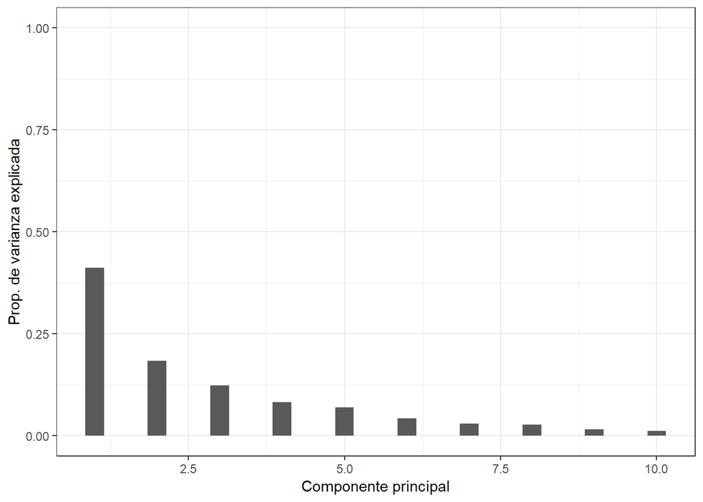

Proporció de la varianza explicada acumulada

```
##  [1] 0.4124213 0.5962744 0.7201885 0.8021325 0.8722878 0.9145760 0.9448342
##  [8] 0.9722812 0.9878029 1.0000000
```

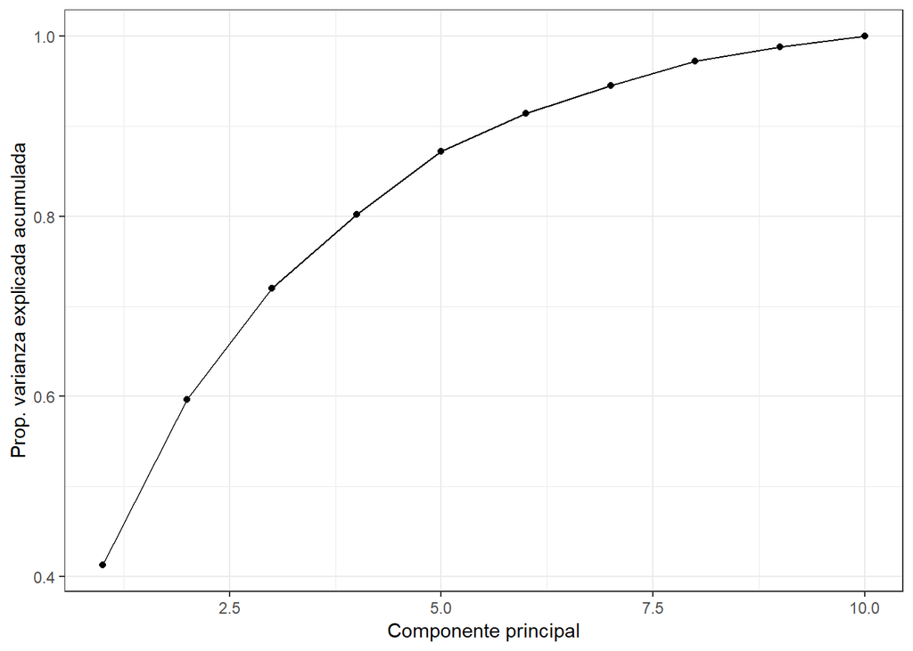

### Gráfico de sedimentación

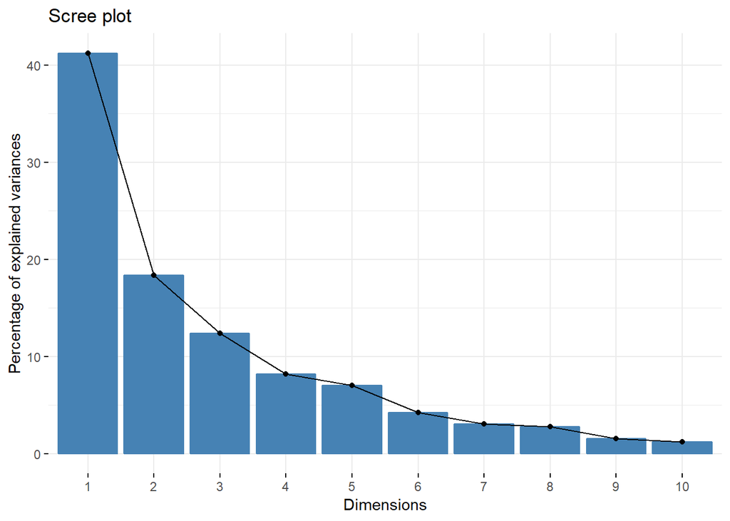

## Proyecciones

### Individuos

Proyección de los individuos

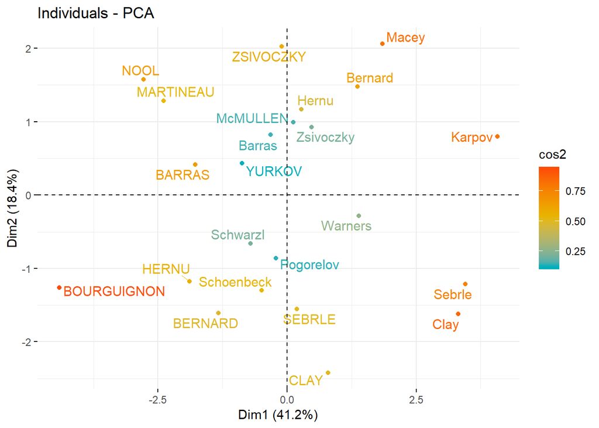

### Variables

Proyección de las variables

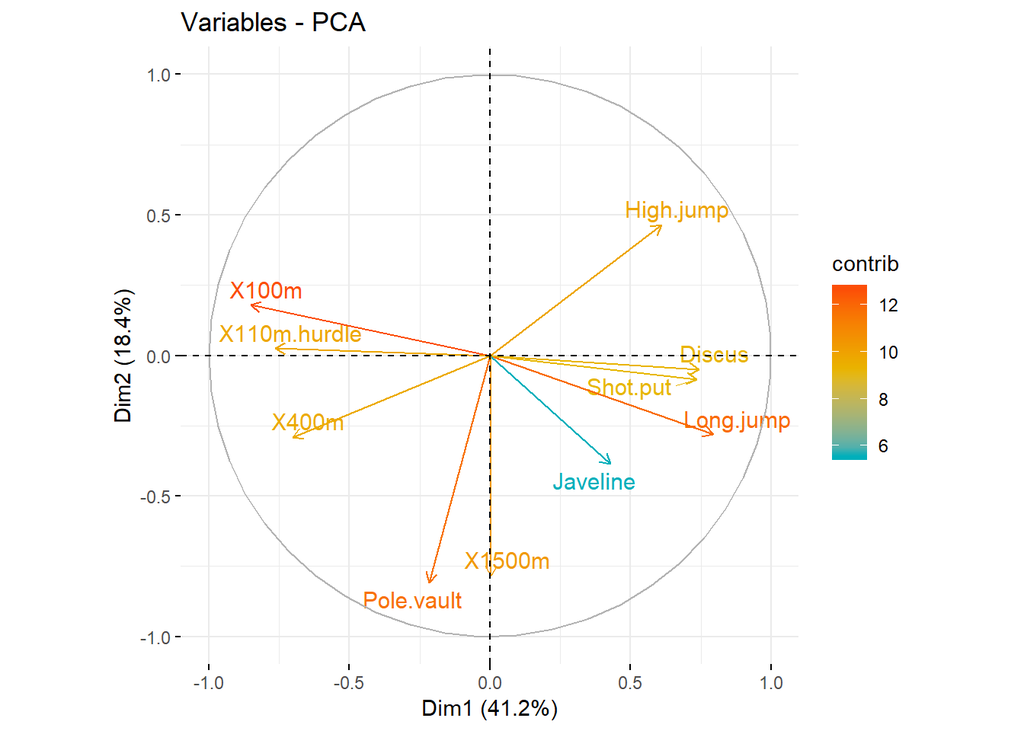

### Individuos - Variables

Proyección de individuos y variables

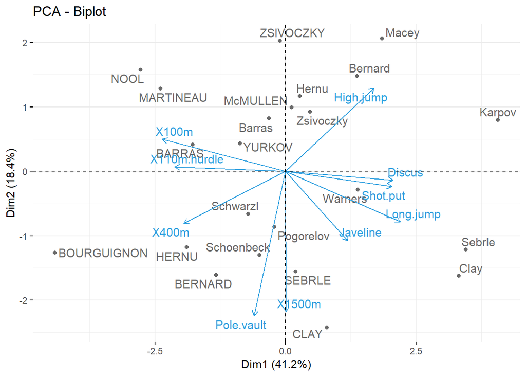

## Otros elementos de análisis

### Agregar nuevos casos

Anteriormente, no habíamos dejado de lado ciertos individuos de la compentencia. Bajo el modelo de PCA ya generado, agreguemos estos casos.

```
##         X100m Long.jump Shot.put High.jump X400m X110m.hurdle
## KARPOV  11.02      7.30    14.77      2.04 48.37        14.09
## WARNERS 11.11      7.60    14.31      1.98 48.68        14.23
## Nool    10.80      7.53    14.26      1.88 48.81        14.80
## Drews   10.87      7.38    13.07      1.88 48.51        14.01
```

[output not shown]

Coordenadas de estos nuevos casos en los CP

```
##                PC1         PC2       PC3        PC4
## KARPOV   0.7772521 -0.76237804 1.5971253  1.6863286
## WARNERS -0.3779697  0.11891968 1.7005146 -0.6908084
## Nool    -0.5468405 -1.93402211 0.4724184 -2.2283706
## Drews   -1.0848227 -0.01703198 2.9818031 -1.5006207
```

Finalmente, así sería la nueva proyección con los nuevos casos

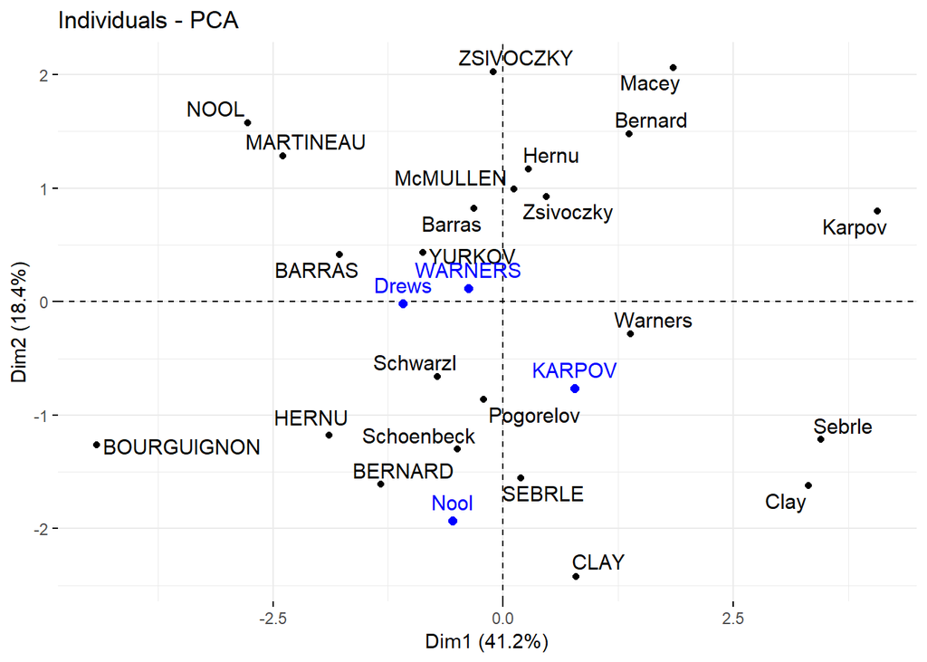

### Agregar variables

#### Adicionar Variables categóricas

EL conjunto de datos decathlon2 contienen una variable cualitativa complementaria en las columnas 13 correspondientes al tipo de competiciones.

Las variables cualitativas / categóricas se pueden usar para colorear individuos por grupos. La variable de agrupación debe ser de la misma longitud que el número de individuos activos (aquí 23).

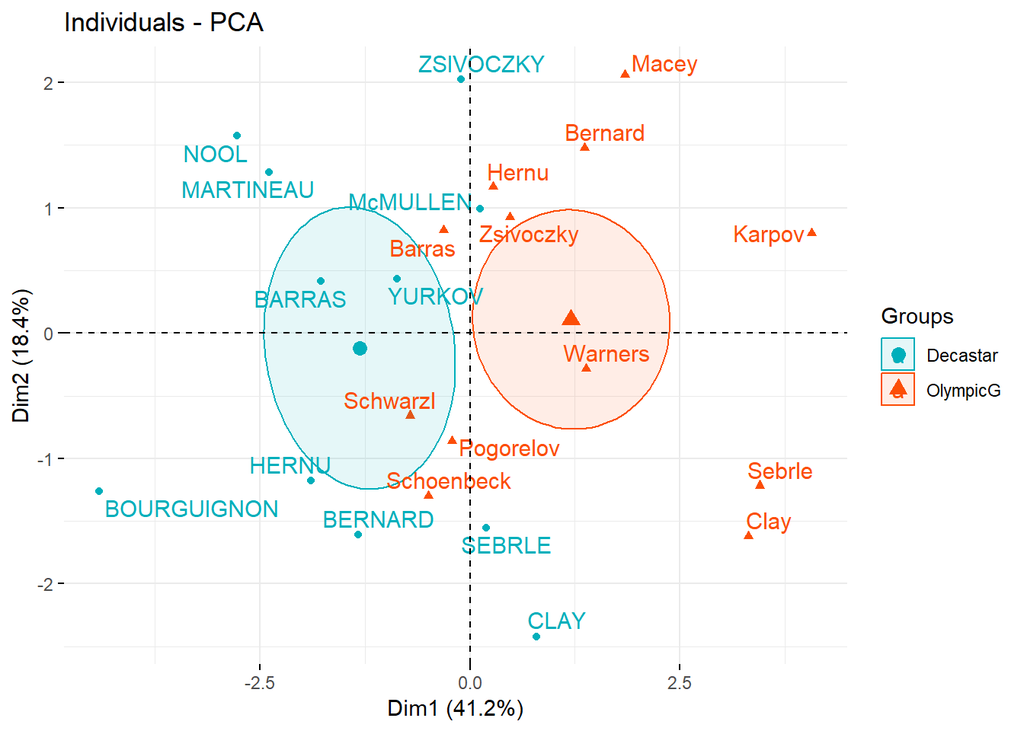

Podría interesar el valor de los centroides

```
## # A tibble: 2 x 3
##   competition Dim.1  Dim.2
##   <fct>       <dbl>  <dbl>
## 1 Decastar    -1.31 -0.119
## 2 OlympicG     1.20  0.109
```

#### Adicionar Variables continuas

También se podrían adicionar variables cuantitativas al análisis

```
##           Rank Points
## SEBRLE       1   8217
## CLAY         2   8122
## BERNARD      4   8067
## YURKOV       5   8036
## ZSIVOCZKY    7   8004
## McMULLEN     8   7995
```

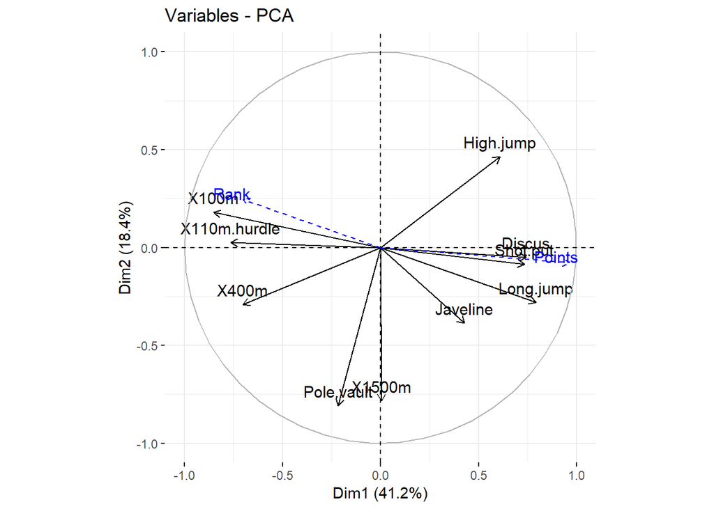